# Pacific herring demography

Joe McGirr

2021-05-03

# 1 Summary

This notebook generates scripts for demographic inference in Pacific herring populations using unlinked biallelic SNPs and the [moments pipeline](https://github.com/dportik/moments_pipeline).

These analyses are exploratory. The 1D and 2D sfs look strange even without a minor allele frequency threshold. It’s likely because low coverage data leads to an overestimate of singletons, doubletons, etc. I experimented with several different ways of generating 1D and 2D sfs.

The `.vcf` was generated with [these commands](https://github.com/joemcgirr/pac_herring/blob/master/Rmarkdown/fastq_to_vcf/Pacific_Herring_fastq_to_vcf.Rmd)

The starting data set is a filtered `.vcf` with 892 Pacific herring low coverage genomes:

minimum depth = 600  
maximum depth = 2000  
minimum base quality = 20  
minimum mapping quality = 30  
genotyping rate > 50% for each population (grouped by sampling location and year) NO MAF threshold

`ph_filtered_snps_minDP600_maxDP2000_minQ20_minMQ30_NS0.5.vcf` available [here](https://osf.io/3cmkr/)

Written by Joe McGirr, postdoc in Andrew Whitehead’s lab.

# 2 Load R libraries and set color palette

```r
knitr::opts_chunk$set(echo = TRUE)
library(ggplot2)
library(tidyverse)
library(reticulate)
library(ggpubr)

# color-blind friendly
# Wong, B. Points of view: Color blindness. Nat Methods (2011).
bla <- "#000000"
blu <- "#0072b2"
grb <- "#56b4e9"
lir <- "#cc79a7"
gre <- "#009e73"
red <- "#d55e00"
org <- "#e69f00"
yel <- "#f0e442"
gry<-  '#BBBBBB'
```

# 3 Load python libraries

```python
import io
import pandas as pd
import numpy as np
import math

def sbatch_header(job,mem,tasks,hours):
    #sbatch submission script header
    script = 'script_' + job + '.sh'
    outfile = io.open(script,'w', newline='\n')
    outfile.write('#!/bin/bash\n\n#SBATCH --job-name='+job+'\n')
    outfile.write('#SBATCH --mem='+mem+'G \n')
    outfile.write('#SBATCH --ntasks='+tasks+' \n')
    outfile.write('#SBATCH -e '+job+'_%A_%a.err \n')
    outfile.write('#SBATCH --time='+hours+':00:00  \n')
    outfile.write('#SBATCH --mail-user=jamcgirr@ucdavis.edu ##email you when job starts,ends,etc\n#SBATCH --mail-type=ALL\n')
    outfile.write('#SBATCH -p high \n\n')
    outfile.close()

def sbatch_header_loop(job,mem,tasks,hours,infile):
    #sbatch submission script header
    script = 'script_' + infile + job + '.sh'
    outfile = io.open(script,'w', newline='\n')
    jobname= infile + job
    outfile.write('#!/bin/bash\n\n#SBATCH --job-name='+jobname+'\n')
    outfile.write('#SBATCH --mem='+mem+'G \n')
    outfile.write('#SBATCH --ntasks='+tasks+' \n')
    outfile.write('#SBATCH -e '+jobname+'_%A_%a.err \n')
    outfile.write('#SBATCH --time='+hours+':00:00 \n')
    outfile.write('#SBATCH --mail-user=jamcgirr@ucdavis.edu ##email you when job starts,ends,etc\n#SBATCH --mail-type=ALL\n')
    outfile.write('#SBATCH -p high \n\n')
    outfile.close()
```

# 4 Creating 2d SFS for moments pipeline

from fantastic beasts, Mikhail Matz 2017: there is a concern that high variation in coverage across samples and populations might affect ANGSD statistics; to avoid this potential issue it is recommended to discard the lowest coverage outliers and down-sample reads from highest-coverage outliers (J. Ross-Ibarra, pers.comm.).

Solution: before generating SFS, use higher minDP threshold and higher genotyping rate. Then LD prune and create 2dSFS for populations.

## 4.1 Find SNPs in LD

Make a list of unlinked sites to subset `.vcf`

example script

```bash
#!/bin/bash

#SBATCH --job-name=LD
#SBATCH --mem=30G
#SBATCH --ntasks=8
#SBATCH -e LD_%A_%a.err
#SBATCH --time=24:00:00
#SBATCH --mail-user=jamcgirr@ucdavis.edu ##email you when job starts,ends,etc
#SBATCH --mail-type=ALL
#SBATCH -p high

module load plink
plink --file /home/jamcgirr/ph/data/vcfs/ph_filtered_snps_minDP600_maxDP2000_minQ20_minMQ30_NS0.5 --indep-pairwise 500 50 0.1 --r2 --out /home/jamcgirr/ph/data/plink/ph_filtered_snps_minDP600_maxDP2000_minQ20_minMQ30_NS0.5_indep_pairwise_500_50_0.1 --threads 8
# make tab delimited
#sed 's/:/\t/g' /home/jamcgirr/ph/data/plink/ph_filtered_snps_minDP600_maxDP2000_minQ20_minMQ30_NS0.5_indep_pairwise_500_50_0.1.prune.in > /home/jamcgirr/ph/data/plink/ph_filtered_snps_minDP600_maxDP2000_minQ20_minMQ30_NS0.5_indep_pairwise_500_50_0.1.prune.in.tab

#command to run: sbatch script_LD.sh
```

## 4.2 LD prune and output depth and number of samples genotyped

example script

```bash
#!/bin/bash

#SBATCH --job-name=LD_prune
#SBATCH --mem=8G
#SBATCH --ntasks=8
#SBATCH -e LD_prune_%A_%a.err
#SBATCH --time=24:00:00
#SBATCH --mail-user=jamcgirr@ucdavis.edu ##email you when job starts,ends,etc
#SBATCH --mail-type=ALL
#SBATCH -p high

module load bcftools
bcftools view -R /home/jamcgirr/ph/data/plink/ph_filtered_snps_minDP600_maxDP2000_minQ20_minMQ30_NS0.5_indep_pairwise_500_50_0.1.prune.in.tab /home/jamcgirr/ph/data/vcfs/ph_filtered_snps_minDP600_maxDP2000_minQ20_minMQ30_NS0.5.vcf.gz -Oz --threads 8 > /home/jamcgirr/ph/data/moments/vcfs/ph_filtered_snps_minDP600_maxDP2000_minQ20_minMQ30_NS0.5_ld0.1.vcf.gz
bcftools query -f '%CHROM %POS %DP %NS\n' /home/jamcgirr/ph/data/moments/vcfs/ph_filtered_snps_minDP600_maxDP2000_minQ20_minMQ30_NS0.5_ld0.1.vcf.gz > /home/jamcgirr/ph/data/moments/vcfs/ph_filtered_snps_minDP600_maxDP2000_minQ20_minMQ30_NS0.5_ld0.1.DP.NS.info


#run: sbatch script_LD_prune.sh
```

## 4.3 Plot distribution of depth and number of samples genotyped

Determine appropriate DP and NS thresholds (more strict)

filters down to 25982 SNPs

```r
info <- read.table("C:/Users/jmcgirr/Documents/Whitehead_Lab/ph/moments/ph_filtered_snps_minDP600_maxDP2000_minQ20_minMQ30_NS0.5_ld0.1.DP.NS.info", header = FALSE, stringsAsFactors = FALSE)
head(info)
```

|  | V1 | V2 | V3 | V4 |
| --- | --- | --- | --- | --- |
| 1 | chr1 | 2624 | 1417 | 554 |
| 2 | chr1 | 2628 | 1403 | 564 |
| 3 | chr1 | 7459 | 1989 | 700 |
| 4 | chr1 | 8600 | 1267 | 608 |
| 5 | chr1 | 10932 | 1337 | 575 |
| 6 | chr1 | 10940 | 1432 | 584 |

```r
quantile(info$V3,0.5)
```

```
##  50%
## 1415
```

```r
892*.7
```

```
## [1] 624.4
```

```r
print("70% genotyping rate and DP > 50th %ile")
```

```
## [1] "70% genotyping rate and DP > 50th %ile"
```

```r
nrow(info[info$V3 > 1600 & info$V4 > 624,])
```

```
## [1] 523946
```

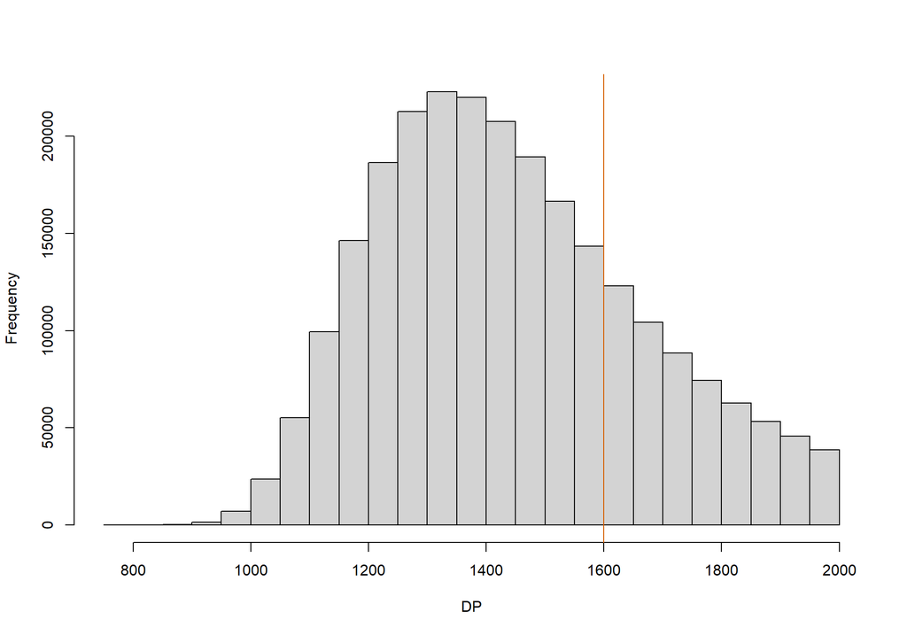

```r
#print("80% genotyping rate and DP > 50th %ile")
#nrow(info[info$V3 > 1600 & info$V4 > 713,])
# 80% genotyping rate and DP > 1340 (1.5*892 ~1.5x coverage)
#nrow(info[info$V3 > 1340 & info$V4 > 713,])


hist(info$V3, xlab = "DP", main = "")
abline(v = 1600, col = red)
```

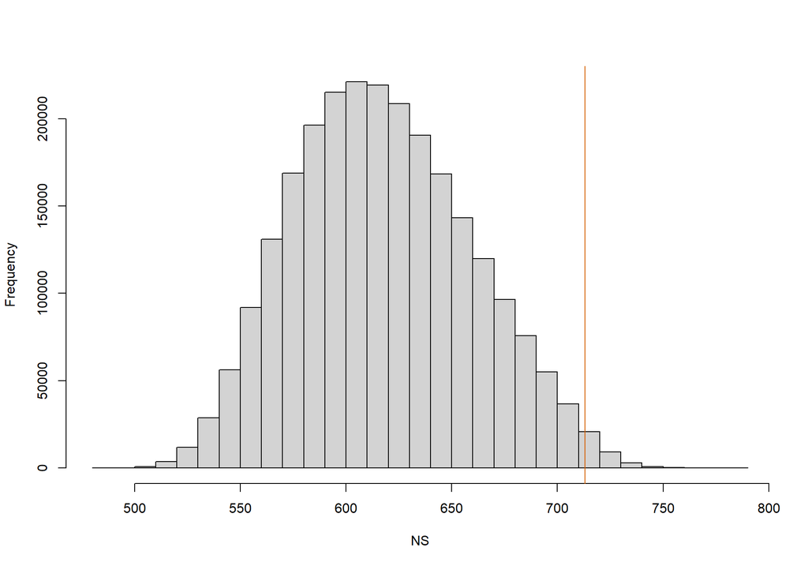

```r
hist(info$V4, xlab = "NS", main = "")
abline(v = 713, col = red)
```

## 4.4 Filter by DP and NS

example script

```bash
#!/bin/bash

#SBATCH --job-name=filter_vcf_for_moments
#SBATCH --mem=8G
#SBATCH --ntasks=4
#SBATCH -e filter_vcf_for_moments_%A_%a.err
#SBATCH --time=24:00:00
#SBATCH --mail-user=jamcgirr@ucdavis.edu ##email you when job starts,ends,etc
#SBATCH --mail-type=ALL
#SBATCH -p high

module load bcftools
bcftools filter -Oz -i 'INFO/DP>1600 && INFO/NS>713' /home/jamcgirr/ph/data/moments/vcfs/ph_filtered_snps_minDP600_maxDP2000_minQ20_minMQ30_NS0.5_ld0.1.vcf.gz -o /home/jamcgirr/ph/data/moments/vcfs/ph_filtered_snps_minDP1600_maxDP2000_minQ20_minMQ30_NS0.8_ld0.1.vcf.gz
bcftools index /home/jamcgirr/ph/data/moments/vcfs/ph_filtered_snps_minDP1600_maxDP2000_minQ20_minMQ30_NS0.8_ld0.1.vcf.gz


#command to run: sbatch script_filter_vcf_for_moments.sh
```

## 4.5 1D SFS

example script

```bash
#!/bin/bash

#SBATCH --job-name=BC17_subset_pops_pruned
#SBATCH --mem=8G
#SBATCH --ntasks=4
#SBATCH -e BC17_subset_pops_pruned_%A_%a.err
#SBATCH --time=24:00:00
#SBATCH --mail-user=jamcgirr@ucdavis.edu ##email you when job starts,ends,etc
#SBATCH --mail-type=ALL
#SBATCH -p high

module load samtools
module load bcftools

bcftools view -S /home/jamcgirr/ph/scripts/angsd/SFS/SFS_by_pop/BC17_plates_1_through_5_rm.txt -Oz /home/jamcgirr/ph/data/moments/vcfs/ph_filtered_snps_minDP1600_maxDP2000_minQ20_minMQ30_NS0.8_ld0.1.vcf.gz --threads 4 > /home/jamcgirr/ph/data/moments/ld_prune/vcfs/BC17_ph_filtered_snps_minDP1600_maxDP2000_minQ20_minMQ30_NS0.8_ld0.1.vcf.gz
/home/jamcgirr/apps/angsd_sep_20/angsd/angsd -doSaf 1 -vcf-pl /home/jamcgirr/ph/data/moments/ld_prune/vcfs/BC17_ph_filtered_snps_minDP1600_maxDP2000_minQ20_minMQ30_NS0.8_ld0.1.vcf.gz -out /home/jamcgirr/ph/data/moments/ld_prune/saf/BC17 -anc /home/jamcgirr/ph/data/c_harengus/c.harengus.fa

/home/jamcgirr/apps/angsd_sep_20/angsd/misc/realSFS /home/jamcgirr/ph/data/moments/ld_prune/saf/BC17.saf.idx -fold 1 > /home/jamcgirr/ph/data/moments/ld_prune/sfs/BC17_folded.sfs
/home/jamcgirr/apps/angsd_sep_20/angsd/misc/realSFS /home/jamcgirr/ph/data/moments/ld_prune/saf/BC17.saf.idx > /home/jamcgirr/ph/data/moments/ld_prune/sfs/BC17_unfolded.sfs


#command to run: sbatch script_BC17_subset_pops_pruned.sh
```

### 4.5.1 Generate SFS scripts

```python
job_name = '_subset_pops_pruned'

saf_dir = '/home/jamcgirr/ph/data/moments/ld_prune/saf/'
sfs_dir = '/home/jamcgirr/ph/data/moments/ld_prune/sfs/'
vcf_name = 'ph_filtered_snps_minDP1600_maxDP2000_minQ20_minMQ30_NS0.8_ld0.1'
infiles = ["BC17","CA17","PWS07","PWS17","PWS91","PWS96","SS06","SS17","SS96","TB06","TB17","TB91","TB96","WA17"]

for infile in infiles:
    script = 'script_' + infile + job_name + '.sh'
    sbatch_header_loop(job_name,'8','4','24', infile)
    o = io.open(script,'a+', newline='\n')

    o.write('module load samtools \n')
    o.write('module load bcftools \n\n')

    # subset master vcf
    o.write('bcftools view -S /home/jamcgirr/ph/scripts/angsd/SFS/SFS_by_pop/'+infile+'_plates_1_through_5_rm.txt -Oz /home/jamcgirr/ph/data/moments/vcfs/'+vcf_name+'.vcf.gz --threads 4 > /home/jamcgirr/ph/data/moments/ld_prune/vcfs/'+infile+'_'+vcf_name+'.vcf.gz \n')
    # make saf from vcf
    o.write('/home/jamcgirr/apps/angsd_sep_20/angsd/angsd -doSaf 1 -vcf-pl /home/jamcgirr/ph/data/moments/ld_prune/vcfs/'+infile+'_'+vcf_name+'.vcf.gz -out /home/jamcgirr/ph/data/moments/ld_prune/saf/'+infile+' -anc /home/jamcgirr/ph/data/c_harengus/c.harengus.fa \n\n')

    # make folded sfs
    o.write('/home/jamcgirr/apps/angsd_sep_20/angsd/misc/realSFS '+saf_dir+infile+'.saf.idx -fold 1 > '+sfs_dir+infile+'_folded.sfs \n')
    # make unfolded sfs
    o.write('/home/jamcgirr/apps/angsd_sep_20/angsd/misc/realSFS '+saf_dir+infile+'.saf.idx > '+sfs_dir+infile+'_unfolded.sfs \n')

    #run sbatch submission
    o.write('\n\n#command to run: sbatch '+script)
    o.close()
```

## 4.6 Plot SFS

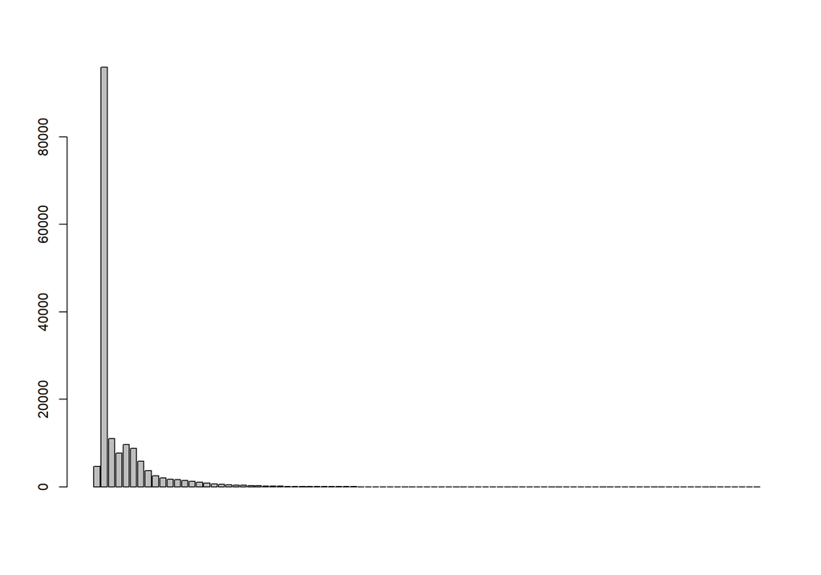

```r
# using SFS from angsd -dosaf -bam

pop_names <- c("BC17","CA17","PWS07","PWS17","PWS91","PWS96","SS06","SS17","SS96","TB06","TB17","TB91","TB96","WA17")

pop_name <- "PWS07"

#for (pop_name in pop_names){
sfs <- read.table(paste("C:/Users/jmcgirr/Documents/Whitehead_Lab/ph/moments/sfs/1D/",pop_name,"_folded.sfs",sep = ""), header = FALSE, stringsAsFactors = FALSE)
sfs <- as.vector(colSums(sfs))
#sfs
barplot(sfs[-c(1,length(sfs))]) #plot variable sites
```

## 4.7 2D SFS

example script

```bash
#!/bin/bash

#SBATCH --job-name=BC17_CA17_dadi_2d_sfs
#SBATCH --mem=8G
#SBATCH --ntasks=4
#SBATCH -e BC17_CA17_dadi_2d_sfs_%A_%a.err
#SBATCH --time=1:00:00
#SBATCH --mail-user=jamcgirr@ucdavis.edu ##email you when job starts,ends,etc
#SBATCH --mail-type=ALL
#SBATCH -p high

module load perl
/home/jamcgirr/apps/angsd/misc/realSFS dadi /home/jamcgirr/ph/data/moments/ld_prune/saf/BC17.saf.idx /home/jamcgirr/ph/data/moments/ld_prune/saf/CA17.saf.idx -sfs /home/jamcgirr/ph/data/moments/ld_prune/sfs/BC17_folded.sfs -sfs /home/jamcgirr/ph/data/moments/ld_prune/sfs/CA17_folded.sfs -P 4 -ref /home/jamcgirr/ph/data/c_harengus/c.harengus.fa -anc /home/jamcgirr/ph/data/c_harengus/c.harengus.fa > /home/jamcgirr/ph/data/moments/2d_sfs_dadi/folded/BC17_CA17_dadi.sfs
/home/jamcgirr/apps/moments/AFS-analysis-with-moments/multimodel_inference/realsfs2dadi.pl /home/jamcgirr/ph/data/moments/2d_sfs_dadi/folded/BC17_CA17_dadi.sfs 64 70 > /home/jamcgirr/ph/data/moments/2d_sfs_dadi/folded/BC17_CA17_dadi_snp.data
rm /home/jamcgirr/ph/data/moments/2d_sfs_dadi/folded/BC17_CA17_dadi.sfs

/home/jamcgirr/apps/angsd/misc/realSFS dadi /home/jamcgirr/ph/data/moments/ld_prune/saf/BC17.saf.idx /home/jamcgirr/ph/data/moments/ld_prune/saf/CA17.saf.idx -sfs /home/jamcgirr/ph/data/moments/ld_prune/sfs/BC17_unfolded.sfs -sfs /home/jamcgirr/ph/data/moments/ld_prune/sfs/CA17_unfolded.sfs -P 4 -ref /home/jamcgirr/ph/data/c_harengus/c.harengus.fa -anc /home/jamcgirr/ph/data/c_harengus/c.harengus.fa > /home/jamcgirr/ph/data/moments/2d_sfs_dadi/unfolded/BC17_CA17_dadi.sfs
/home/jamcgirr/apps/moments/AFS-analysis-with-moments/multimodel_inference/realsfs2dadi.pl /home/jamcgirr/ph/data/moments/2d_sfs_dadi/unfolded/BC17_CA17_dadi.sfs 64 70 > /home/jamcgirr/ph/data/moments/2d_sfs_dadi/unfolded/BC17_CA17_dadi_snp.data
rm /home/jamcgirr/ph/data/moments/2d_sfs_dadi/unfolded/BC17_CA17_dadi.sfs
```

### 4.7.1 Generate SFS scripts

```python
job_name = '_dadi_2d_sfs'

realSFS = '/home/jamcgirr/apps/angsd/misc/realSFS'
saf_dir = '/home/jamcgirr/ph/data/moments/ld_prune/saf/'
sfs_dir = '/home/jamcgirr/ph/data/moments/ld_prune/sfs/'

pop_n = {"BC17":"64","CA17":"70","PWS07":"46","PWS17":"56","PWS91":"58","PWS96":"72","SS06":"41","SS17":"64","SS96":"78","TB06":"52","TB17":"72","TB91":"74","TB96":"73","WA17":"72"}
infiles = ["BC17_CA17","BC17_WA17","PWS07_PWS17","PWS07_SS06","PWS17_BC17","PWS17_CA17","PWS17_SS17","PWS17_WA17","PWS91_PWS07","PWS91_PWS17","PWS91_PWS96","PWS96_PWS07","PWS96_PWS17","PWS96_SS96","SS06_SS17","SS17_BC17","SS17_CA17","SS17_WA17","SS96_SS06","SS96_SS17","TB06_PWS07","TB06_SS06","TB06_TB17","TB17_BC17","TB17_CA17","TB17_PWS17","TB17_SS17","TB17_WA17","TB91_TB06","TB91_TB17","TB91_TB96","TB96_PWS96","TB96_SS96","TB96_TB06","TB96_TB17","WA17_CA17"]

for infile in infiles:
    script = 'script_' + infile + job_name + '.sh'
    sbatch_header_loop(job_name,'8','4','1', infile)
    o = io.open(script,'a+', newline='\n')

    pops = ''.join(infile).split("_")

    o.write('module load perl \n')

    # folded
    o.write(realSFS+' dadi '+saf_dir+pops[0]+'.saf.idx '+saf_dir+pops[1]+'.saf.idx -sfs '+sfs_dir+pops[0]+'_folded.sfs -sfs '+sfs_dir+pops[1]+'_folded.sfs -P 4 -ref /home/jamcgirr/ph/data/c_harengus/c.harengus.fa -anc /home/jamcgirr/ph/data/c_harengus/c.harengus.fa > /home/jamcgirr/ph/data/moments/2d_sfs_dadi/folded/'+pops[0]+'_'+pops[1]+'_dadi.sfs \n')
    o.write('/home/jamcgirr/apps/moments/AFS-analysis-with-moments/multimodel_inference/realsfs2dadi.pl /home/jamcgirr/ph/data/moments/2d_sfs_dadi/folded/'+pops[0]+'_'+pops[1]+'_dadi.sfs '+pop_n[pops[0]]+' '+pop_n[pops[1]]+' > /home/jamcgirr/ph/data/moments/2d_sfs_dadi/folded/'+pops[0]+'_'+pops[1]+'_dadi_snp.data \n')
    o.write('rm /home/jamcgirr/ph/data/moments/2d_sfs_dadi/folded/'+pops[0]+'_'+pops[1]+'_dadi.sfs \n\n')

    # unfolded
    o.write(realSFS+' dadi '+saf_dir+pops[0]+'.saf.idx '+saf_dir+pops[1]+'.saf.idx -sfs '+sfs_dir+pops[0]+'_unfolded.sfs -sfs '+sfs_dir+pops[1]+'_unfolded.sfs -P 4 -ref /home/jamcgirr/ph/data/c_harengus/c.harengus.fa -anc /home/jamcgirr/ph/data/c_harengus/c.harengus.fa > /home/jamcgirr/ph/data/moments/2d_sfs_dadi/unfolded/'+pops[0]+'_'+pops[1]+'_dadi.sfs \n')
    o.write('/home/jamcgirr/apps/moments/AFS-analysis-with-moments/multimodel_inference/realsfs2dadi.pl /home/jamcgirr/ph/data/moments/2d_sfs_dadi/unfolded/'+pops[0]+'_'+pops[1]+'_dadi.sfs '+pop_n[pops[0]]+' '+pop_n[pops[1]]+' > /home/jamcgirr/ph/data/moments/2d_sfs_dadi/unfolded/'+pops[0]+'_'+pops[1]+'_dadi_snp.data \n')
    o.write('rm /home/jamcgirr/ph/data/moments/2d_sfs_dadi/unfolded/'+pops[0]+'_'+pops[1]+'_dadi.sfs \n\n')

    #run sbatch submission
    o.write('\n\n#command to run: sbatch '+script)
    o.close()
```

## 4.8 Plot 2D SFS

```python
#import moments
#import matplotlib
pops = ["SS17","TB17"]
#projections
proj = 82
dd = moments.Misc.make_data_dict('C:/Users/jmcgirr/Documents/Whitehead_Lab/ph/moments/downsample/chr1_5mb/'+pops[0] + '_' + pops[1]+'_dadi_snp.data')
fs = moments.Spectrum.from_data_dict(dd,pop_ids=[pops[0], pops[1]],projections=[proj, proj],polarized = True)
S = fs.S()
Fst = fs.Fst()
print(S)
print(Fst)

# moments.Plotting.plot_single_2d_sfs(fs, vmin =1)
# matplotlib.pyplot.savefig("C:/Users/jmcgirr/Documents/Whitehead_Lab/ph/moments/downsample/" + pops[0] + "_" + pops[1] + "_2d_sfs.png")
# matplotlib.pyplot.close()
```

# 5 Testing simple demographic models with moments pipeline

Results (migration rates, time at split, Ne) are inconsistent.

## 5.1 one population split into two pops with symmetrical migration

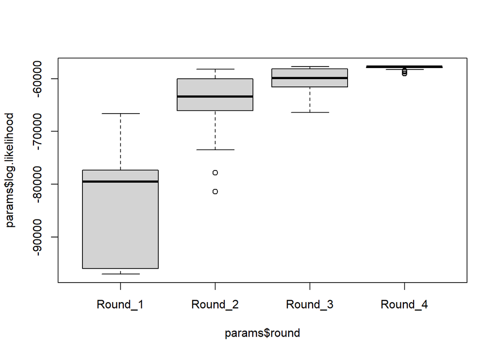

```
## $stats
##           [,1]      [,2]      [,3]      [,4]
## [1,] -97030.14 -73480.49 -66409.89 -58266.38
## [2,] -96000.07 -66036.34 -61597.58 -57957.11
## [3,] -79491.82 -63416.45 -59921.08 -57747.94
## [4,] -77343.27 -60004.01 -58139.23 -57695.92
## [5,] -66594.51 -58236.88 -57702.59 -57675.76
##
## $n
## [1] 10 20 50 60
##
## $conf
##           [,1]      [,2]      [,3]      [,4]
## [1,] -88813.50 -65547.67 -60693.84 -57801.22
## [2,] -70170.13 -61285.23 -59148.33 -57694.67
##
## $out
## [1] -77797.64 -81397.48 -58489.21 -58609.74 -58719.28 -58995.09 -59018.97
## [8] -59021.75
##
## $group
## [1] 2 2 4 4 4 4 4 4
##
## $names
## [1] "Round_1" "Round_2" "Round_3" "Round_4"
##
## [1] "optimized parameter set for empirical data:"
## [1] "0.4296" "0.3843" "0.007"  "0.05"
## [1] "theta"
## [1] 15265.81
```

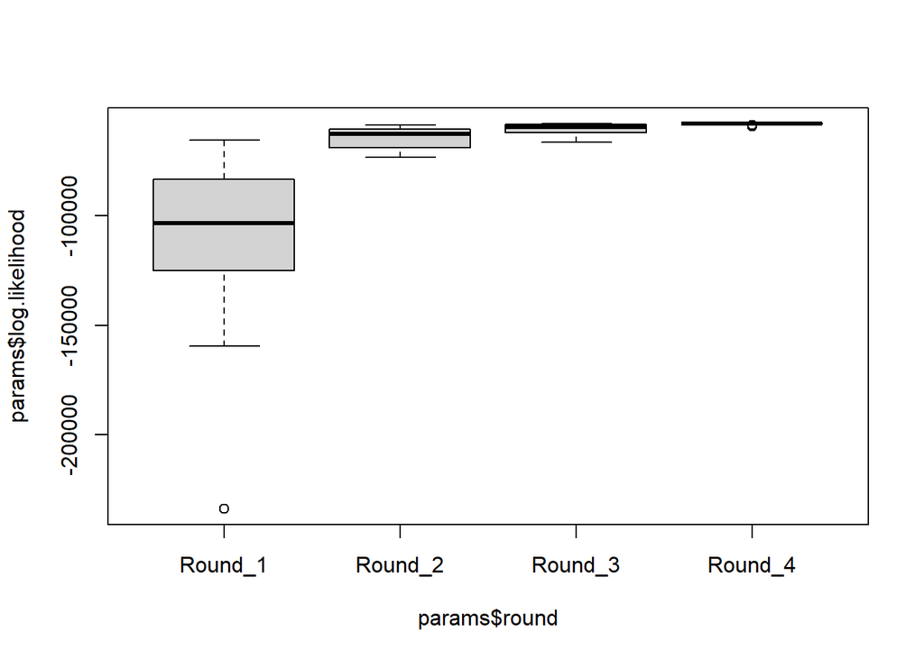

```
## $stats
##            [,1]      [,2]      [,3]      [,4]
## [1,] -159538.83 -73260.38 -66260.29 -58417.61
## [2,] -124994.43 -68971.50 -62073.06 -58014.49
## [3,] -103239.60 -62415.85 -59502.29 -57767.91
## [4,]  -83251.49 -60257.64 -58172.97 -57712.18
## [5,]  -65461.85 -58443.55 -57726.76 -57677.72
##
## $n
## [1] 10 20 50 60
##
## $conf
##            [,1]      [,2]      [,3]      [,4]
## [1,] -124096.04 -65494.44 -60373.75 -57829.57
## [2,]  -82383.16 -59337.25 -58630.84 -57706.25
##
## $out
## [1] -233853.99  -58536.61  -58588.98  -58719.32  -58906.21  -59051.10
##
## $group
## [1] 1 4 4 4 4 4
##
## $names
## [1] "Round_1" "Round_2" "Round_3" "Round_4"
##
## [1] "optimized parameter set for empirical data:"
## [1] "0.4299" "0.3811" "0.0102" "0.0501"
## [1] "theta"
## [1] 15282.14
```

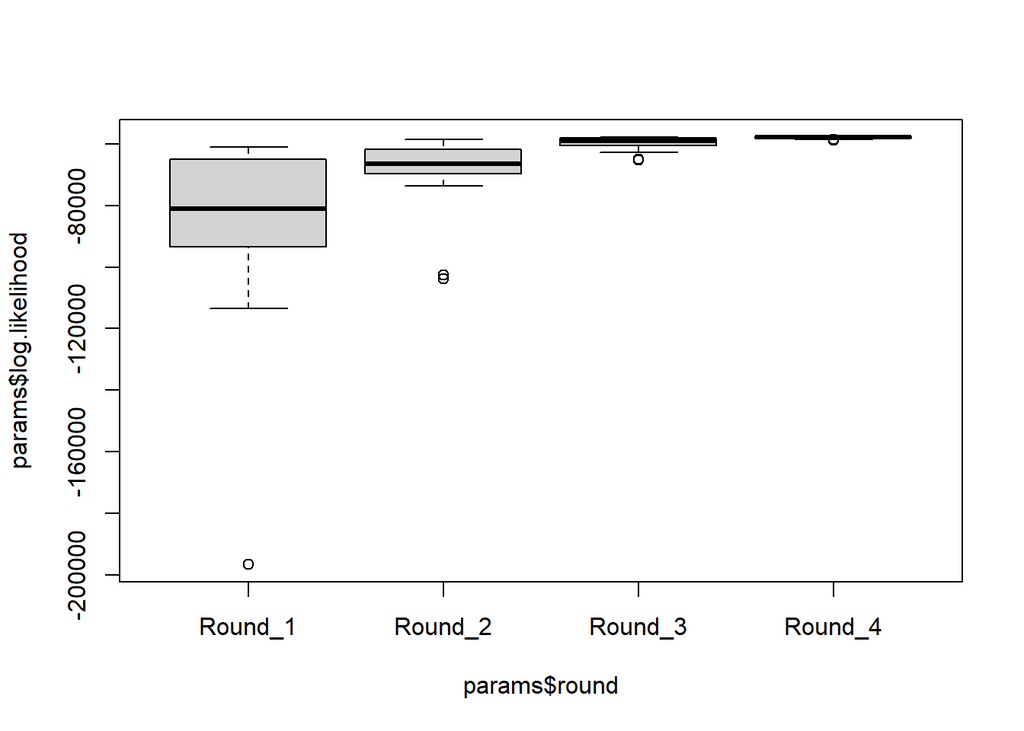

```
## $stats
##            [,1]      [,2]      [,3]      [,4]
## [1,] -113561.87 -73533.48 -62796.55 -58462.35
## [2,]  -93514.26 -69785.90 -60581.47 -58015.61
## [3,]  -81156.03 -66375.79 -59109.73 -57747.51
## [4,]  -65070.83 -61783.48 -58094.26 -57692.04
## [5,]  -61125.97 -58621.36 -57719.39 -57671.27
##
## $n
## [1] 10 20 50 60
##
## $conf
##           [,1]      [,2]      [,3]      [,4]
## [1,] -95367.50 -69203.04 -59665.48 -57813.51
## [2,] -66944.56 -63548.55 -58553.97 -57681.52
##
## $out
##  [1] -196651.84 -102607.41 -103915.13  -64945.29  -65351.60  -58552.18
##  [7]  -58552.99  -58602.87  -58648.66  -58682.55  -58873.30
##
## $group
##  [1] 1 2 2 3 3 4 4 4 4 4 4
##
## $names
## [1] "Round_1" "Round_2" "Round_3" "Round_4"
##
## [1] "optimized parameter set for empirical data:"
## [1] "0.4237" "0.3846" "0.0001" "0.0501"
## [1] "theta"
## [1] 15294.54
```

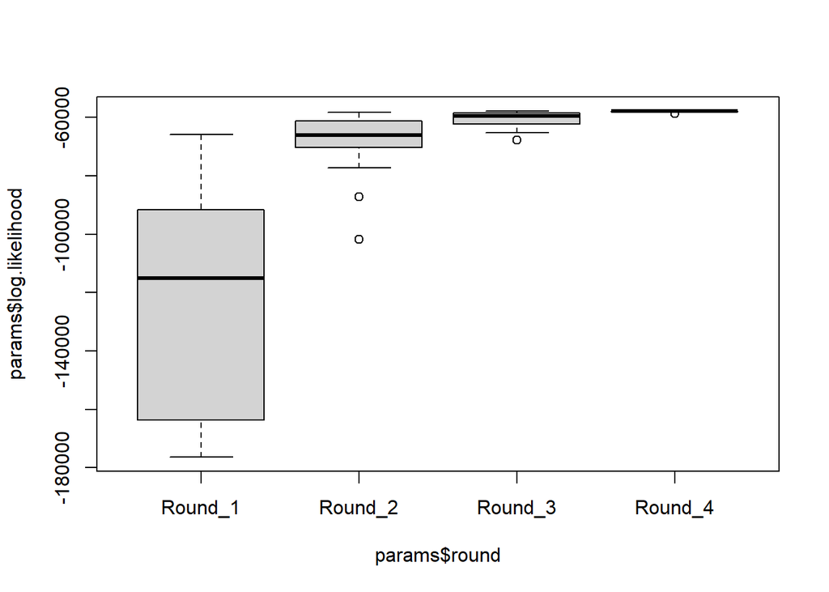

```
## $stats
##            [,1]      [,2]      [,3]      [,4]
## [1,] -176363.35 -77273.22 -65286.82 -58317.61
## [2,] -163591.35 -70280.40 -62199.47 -58009.51
## [3,] -115091.18 -66105.56 -59400.11 -57802.76
## [4,]  -91555.67 -61209.01 -58497.21 -57703.37
## [5,]  -65880.78 -58204.06 -57706.93 -57677.97
##
## $n
## [1] 10 20 50 60
##
## $conf
##            [,1]      [,2]      [,3]      [,4]
## [1,] -151083.08 -69310.47 -60227.36 -57865.21
## [2,]  -79099.28 -62900.65 -58572.86 -57740.32
##
## $out
## [1]  -87159.34 -101833.72  -67824.41  -58641.81  -58648.39
##
## $group
## [1] 2 2 3 4 4
##
## $names
## [1] "Round_1" "Round_2" "Round_3" "Round_4"
##
## [1] "optimized parameter set for empirical data:"
## [1] "0.4215" "0.3776" "0.009"  "0.0493"
## [1] "theta"
## [1] 15336.49
```

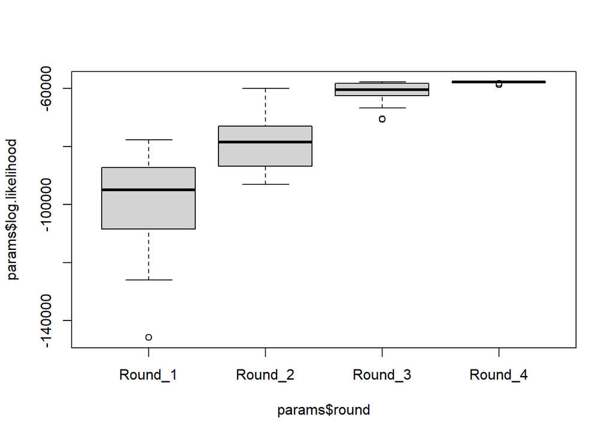

```
## $stats
##            [,1]      [,2]      [,3]      [,4]
## [1,] -126065.90 -93024.17 -66769.39 -58121.93
## [2,] -108413.72 -86825.89 -62514.12 -57879.51
## [3,]  -94996.15 -78422.02 -60467.71 -57754.15
## [4,]  -87339.45 -72971.84 -58293.87 -57705.90
## [5,]  -77782.97 -59930.59 -57769.85 -57682.00
##
## $n
## [1] 10 20 50 60
##
## $conf
##           [,1]      [,2]      [,3]      [,4]
## [1,] -105525.7 -83316.64 -61410.71 -57789.56
## [2,]  -84466.6 -73527.40 -59524.72 -57718.74
##
## $out
## [1] -145844.23  -70535.33  -70635.51  -58209.10  -58228.60  -58258.94  -58697.10
##
## $group
## [1] 1 3 3 4 4 4 4
##
## $names
## [1] "Round_1" "Round_2" "Round_3" "Round_4"
##
## [1] "optimized parameter set for empirical data:"
## [1] "0.426"  "0.3831" "0.018"  "0.0504"
## [1] "theta"
## [1] 15293.08
```

```r
# http://evomics.org/wp-content/uploads/2016/01/dadi.pdf
# In dadi, all parameters are scaled by the effective size of the ancestral population. To find
# that effective size, we use the relationship θ = 4NeµL, where µ is the per-base mutation
# rate, and L is length of sequence from which the SNPs came. So Ne = θ/4µL.

model_name <- "sym_mig_2_pop"
pops <- "PWS17_SS17"
pops <- "PWS17_TB17"
pops <- "SS17_TB17"


for (i in c(1:5)){
#params <- read.delim(paste("C:/Users/jmcgirr/Documents/Whitehead_Lab/ph/moments/moments_pipeline/models/",model_name,"/",pops,"/V4_Number_",i,".sym_mig.optimized.txt", sep = ""))

params <- read.delim(paste("C:/Users/jmcgirr/Documents/Whitehead_Lab/ph/moments/downsample/chr1_5mb/",pops,"/V5_Number_",i,".sym_mig.optimized.txt", sep = ""))
params <- params[order(params$AIC),]
head(params)
params <- params %>% separate(Replicate, c("round","replicate"), remove = TRUE,sep = "_R")

print(boxplot(params$log.likelihood~params$round))
opt_params <- strsplit(params[1,8], ",")[[1]]
print("optimized parameter set for empirical data:")
print(opt_params)
print("theta")
print(params$theta[1])

}
```

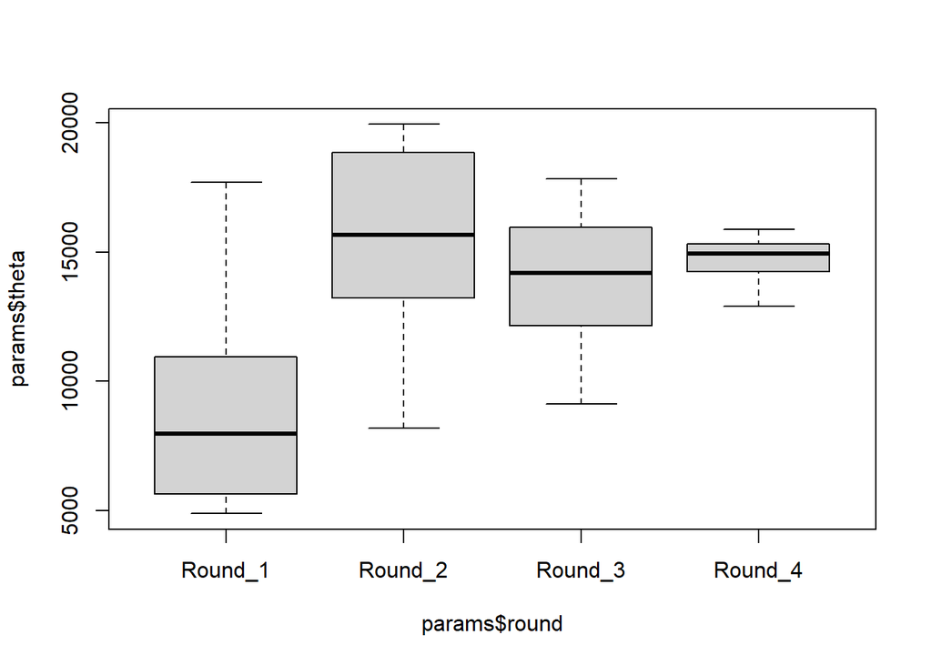

```r
# best run
i <- 2

#parameter ranges
params <- read.delim(paste("C:/Users/jmcgirr/Documents/Whitehead_Lab/ph/moments/downsample/chr1_5mb/",pops,"/V5_Number_",i,".sym_mig.optimized.txt", sep = ""))
params <- params[order(params$AIC),]
params <- params %>% separate(Replicate, c("round","replicate"), remove = TRUE,sep = "_R")
#print(boxplot(params$log.likelihood~params$round))
params <- params %>% separate(optimized_params.nu1..nu2..m..T., into = c("nu1","nu2","m","t"), sep = ",")
boxplot(params$theta~params$round)
```

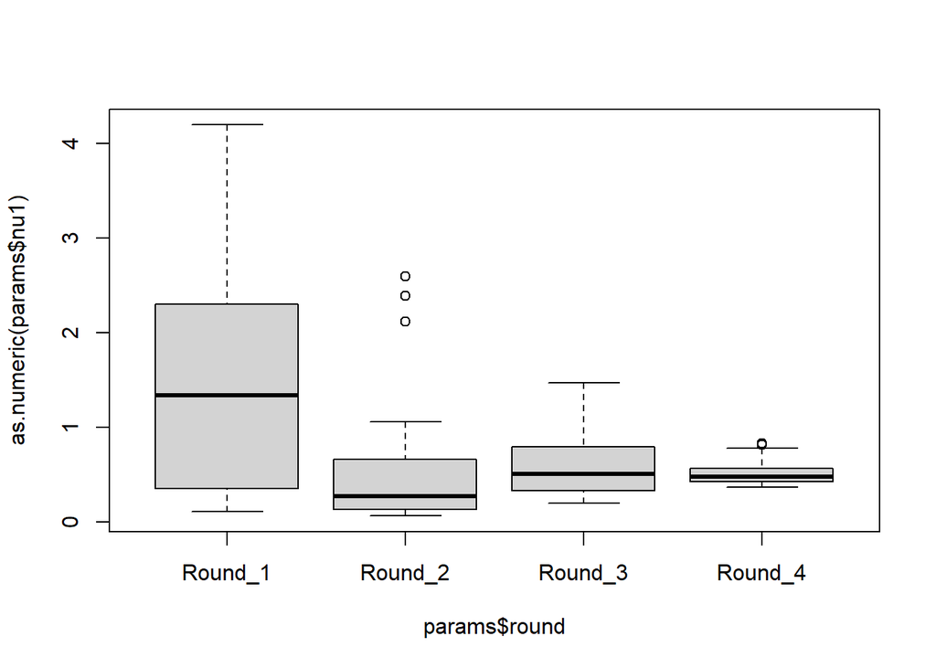

```r
boxplot(as.numeric(params$nu1)~params$round)
```

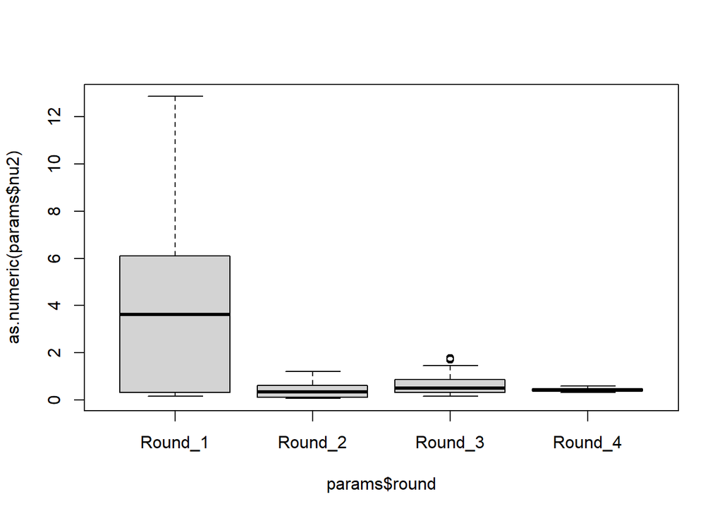

```r
boxplot(as.numeric(params$nu2)~params$round)
```

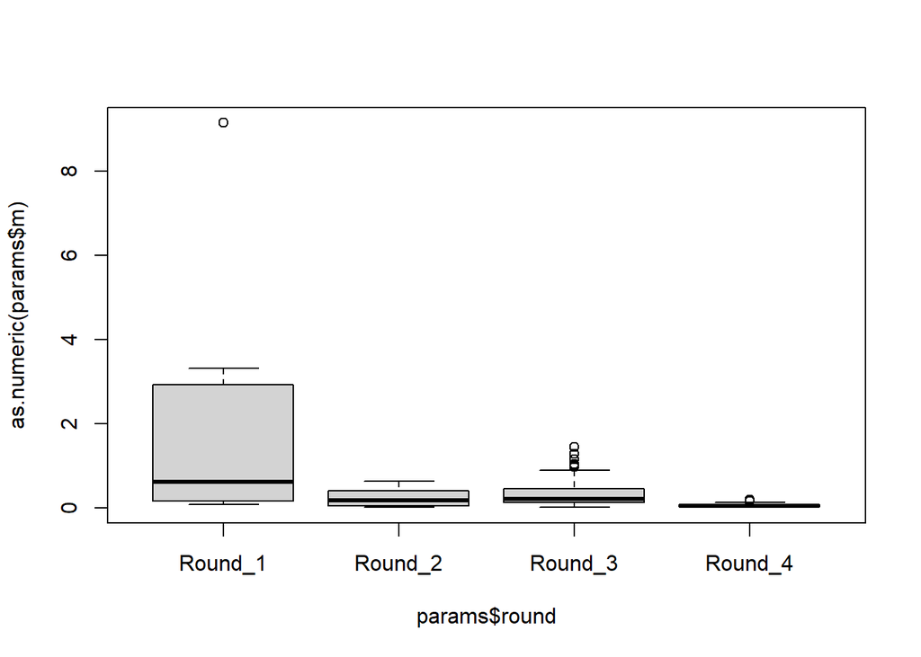

```r
boxplot(as.numeric(params$m)~params$round)
```

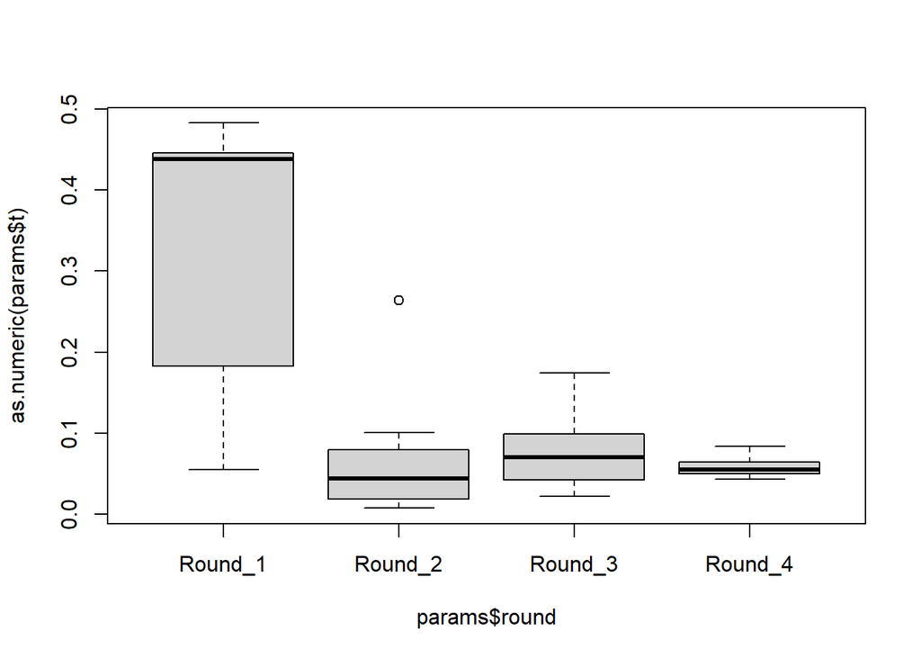

```r
boxplot(as.numeric(params$t)~params$round)
```

```r
# calcualte split time and pop size
params <- read.delim(paste("C:/Users/jmcgirr/Documents/Whitehead_Lab/ph/moments/downsample/chr1_5mb/",pops,"/V5_Number_",i,".sym_mig.optimized.txt", sep = ""))
params <- params[order(params$AIC),]
params <- params %>% separate(Replicate, c("round","replicate"), remove = TRUE,sep = "_R")
#print(boxplot(params$log.likelihood~params$round))
opt_params <- strsplit(params[1,8], ",")[[1]]

   # Split into two populations, with symmetric migration.
   # nu1: Size of population 1 after split.
   # nu2: Size of population 2 after split.
   # m: Migration rate between populations (2*Na*m)
   # T: Time in the past of split (in units of 2*Na generations)

theta <- as.numeric(params$theta[1])
nu1 <- as.numeric(opt_params[1])
nu2 <- as.numeric(opt_params[2])
m <- as.numeric(opt_params[3])
t <- as.numeric(opt_params[4])
m
```

```
## [1] 0.0102
```

```r
t
```

```
## [1] 0.0501
```

```r
# generation time
g <- 6
# atlantic herring mutation rate
mu <- 2.0e-9


#https://groups.google.com/g/dadi-user/c/DYrpTHCcC_I/m/nl3f2eGSAQAJ
# estimate of L needs to account for filtering
# L = (genome size) * (filtered SNPs)/(total SNPs)
#L <- 7.26e8  * (200000/8732577)

#using 5MB of chr1
L <- 5000000
#https://groups.google.com/g/dadi-user/c/5HtpVOCO2nc/m/yYbh48MLBAAJ
# effective size of current population
0.003/(4*mu)
```

```
## [1] 375000
```

```r
# effective size of ancestral population
Nref <- theta / (4* mu* L)
Nref
```

```
## [1] 382053.5
```

```r
# Time since split
t*2*Nref*4
```

```
## [1] 153127
```

```r
# thetas <-c()
# nu1s   <-c()
# nu2s   <-c()
# ms     <-c()
# ts     <-c()
# for (param_row in c(1:nrow(params))){
# opt_params <- strsplit(params[1,8], ",")[[param_row]]
#
# theta <- c(thetas ,as.numeric(params$theta[param_row]))
# nu1   <- c(nu1s   ,as.numeric(opt_params[1]))
# nu2   <- c(nu2s   ,as.numeric(opt_params[2]))
# m     <- c(ms     ,as.numeric(opt_params[3]))
# t     <- c(ts     ,as.numeric(opt_params[4]))
#
# }
```